# HiFi Full-length ITS Analysis Report

Report generated on: Thursday, 28 August 2025

## Classification using Naive Bayes classifier against Unite

Pacific Bioscience Kinnex data was generated at the Nucleomics Core using custom primers specific for the eukaryote ITS locus and produce HiFi data for this analysis.

The primer sequences used in this project were:

- forp TCCGTAGGTGAACCTGC, (ITS1) specific to the SSU rDNA subunit
- revp CCTSCSCTTANTDATATGC, (ITS4ngsUni) specific to the LSU rDNA subunit

The primer pair is designed to amplify fungal ITS regions broadly and inclusively, covering both Ascomycetes and Basidiomycetes, with degenerate bases for the reverse primer to capture diverse fungal groups and reduce bias (ref: Tedersoo and Lindahl, 2016, doi:10.1111/1758-2229.12438).

ITS containing amplicons were processed using the Kinnex 16S kit to produce 16mer concatemers sequenced as HiFi reads then deconcatenated and demultiplexed using pacbio software (skera and lima) and standard parameters (no size cutoff).

The raw sequencing data was analyzed using the **[NextITS pipeline](https://github.com/vmikk/NextITS)** (version: vmiks_nextits_0.8.2) and the full NextITS nextflow result folder is provided and with more information about the primary analysis results, the raw read processing and quality controls included in the pipeline.

The ASV sequences obtained from the final LULU step (OTUs_LULU.fa) and their respective counts across samples (OTU_table.txt.gz) were used to generate this report and provide initial insights into the data.

The NextITS *OTUs_LULU.fa* sequences were classified with the Qiime2 Naive Bayes classifier against the **Unite database** (v10.0 - 2025-02-19 - fungi; fungi_99pc_2025-02-19 classifier generated using Qiime amplicon version 2025-7). The obtained taxonomy (TAX) was combined to the sample metadata information derived from the customer sample-sheet (SAMPLES), and the merged ASV count table generated by NextITS (OTU) to obtain a fully functional R phyloseq object used in this report.

The *OTUs_LULU.fa* sequences were also used to measure the distribution of ASV lengths in the data as ITS regions are quite variable in length as opposed to the rather conserved 16S region in prokaryotes.

Note: A deeper exploration of the data will be required to obtained solid results and can be initiated using the provided Phyloseq Object (physeq_object.rds and physeq_object.biom for your convenience).

## Analysis of taxon distribution and relative abundance

The amplicon data is filter at two key taxonomy levels to return taxon diversity in the project samples either at Genus or Species level. Note that the ASVs which did not reach this depth of classification are absent from the plots.

### Genus level results

The Genus classification results are used to produce a ASV count heatmap from the top 95% results (leaving out the 5% lowest count taxa).

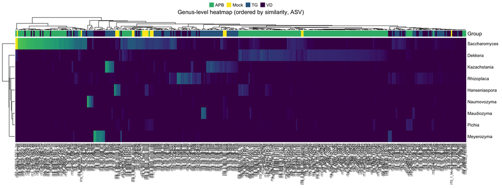

.

### Species level results

The Species classification results are used to produce a ASV count heatmap from the top 95% results (leaving out the 5% lowest count taxa).

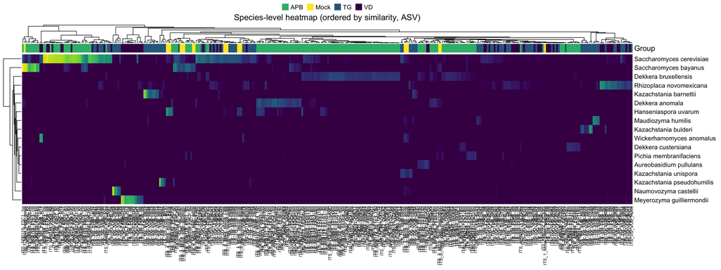

.

### PCA plot

A variance analysis is made on the full based on taxonomy counts to identify subset of samples in the project with similar profiles and evaluate their coincidence with customer-defined groups.

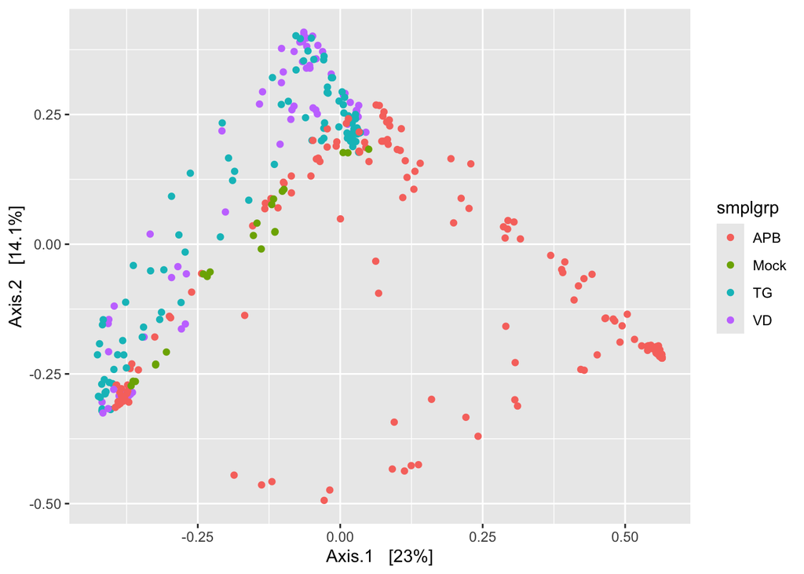

.

## Distribution of ITS amplicons lengths

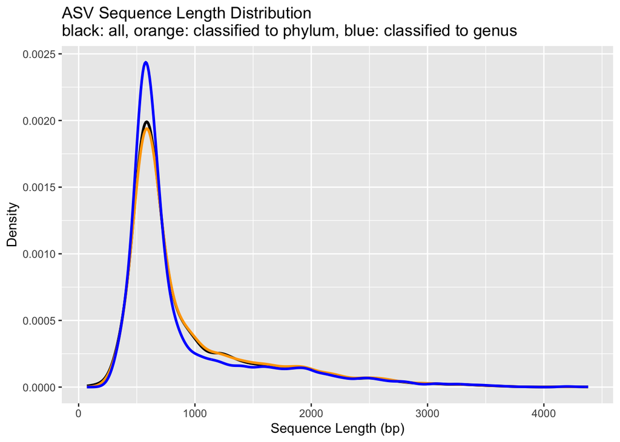

.

## Tool and Data Versions

```
QIIME environment: qiime2-amplicon-2025.7
Date: Tue Aug 26 03:57:37 PM CEST 2025
Classification parameters:
Input file: OTUs_LULU.fa
UNITE version: 2025-02-19
Taxon group: fungi
Cluster ID: 99
Classifier QZA: unite-classifier-fungi_99pc_2025-02-19.qza
Sequences QZA: unite-sequences-fungi_99pc_2025-02-19.qza
Taxonomy QZA: unite-taxonomy-fungi_99pc_2025-02-19.qza
Trainset FASTA: unite-trainset-fungi_99pc_2025-02-19.fa.gz
Sklearn output: sklearn_classified_OTUs_LULU.tsv
VSEARCH output: vsearch_classified_OTUs_LULU.tsv
Threads: 68
```